# Approche “Modèle sur mesure simple”

On utilise le Concepteur / Designer d’un service Azure Machine Learning, interface graphique drag & drop, pour développer rapidement un modèle classique permettant de prédire le sentiment associé à un tweet.

[figure not shown]

On compare deux modèles entraînés puis on sélectionne le meilleur pour un déploiement.

Avant d'entraîner nos modèles, on prépare nos données :

### **Text preprocessing**

- On échantillone notre jeu de données pour ne garder que 2% de tweets, équilibré sur la variable target
- On nettoie les tweets :
  - Expand verb contractions
  - Remove stop words
  - Use lemmatization
  - Detect sentences by adding a sentence terminator "|||" that can be used by the n-gram features extractor module
  - Normalize case to lowercase
  - Remove numbers
  - Remove special characters
  - Remove duplicate characters
  - Remove email addresses
  - Remove URLs
  - Normalize backslashes to slashes
  - Split tokens on special characters
- On supprime les colonnes inutiles

### **Text vectorization**

On va vectoriser nos tweets de 2 manières pour nos 2 modèles :

#### **Feature Hashing**

- Paramètres :
  - Hashing bitsize: 10
  - N-grams: 2

#### **Extract N-Gram Features from Text**

- Paramètres :
  - N-grams size: 2
  - Weighting function: TF-IDF Weight
  - Minimum word length: 3
  - Maximum word length: 25
  - Minimum n-gram document absolute frequency: 5
  - Maximum n-gram document ratio: 1
  - Normalize n-gram feature vectors: True

## Entraînement des modèles

On va entrainer une Régression logistique sur les 2 types de vectorisatiobs précédentes:

- Paramètres:
  - Optimization tolerance: 1e-07
  - L2 regularization weight: 1.0

## Résultats

[figure not shown]

Le modèle avec la vectorisation N-Gram Features est le plus performant, voici les métriques :

- **Précision : 0.725**
- **ROC AUC : 0.81**

## Déploiement du modèle

On va déployer ce modèle dans un web service, pour ensuite l'appeler via une requête API et le tester sur quelques exemples.

[figure not shown]

## Test du modèle

```python
%reload_ext autoreload
%autoreload 2
%matplotlib inline

import urllib.request
import json
import os
import pandas as pd

import src.helpers.data_helpers as dth

# Charger les variables d'environnement depuis le ficher .env
from dotenv import load_dotenv

load_dotenv()
url = os.getenv("AZURE_API_DESIGNER_ENDPOINT")
api_key = os.getenv("AZURE_API_DESIGNER_KEY")
```

On recupère un échantillion de 2000 tweets depuis le jeu de données

```python
# Charger les données depuis le fichier csv
data_tweets = pd.read_csv('data/training.1600000.processed.noemoticon.csv', sep=',', encoding = "ISO-8859-1", header=None, names=['target', 'id', 'date', 'flag', 'user', 'text'])

# Ne garder que les colonnes nécessaires
data_tweets = data_tweets[["text", "target"]]


# Echantillon de 1000 tweets positifs et 1000 tweets négatifs
sample_negatif = data_tweets[data_tweets['target'] == 0].sample(n = 1000)
sample_positif = data_tweets[data_tweets['target'] == 4].sample(n = 1000)

sample = pd.concat([sample_negatif, sample_positif])
```

On prépare la requête API

```python
data =  {
  "Inputs": {
    "WebServiceInput0": []
  },
  "GlobalParameters": {}
}
```

```python
for tweet in sample['text']:
    data['Inputs']['WebServiceInput0'].append({"Column6": tweet})
```

Appel API pour tester le modèle déployé

```python
body = str.encode(json.dumps(data))

# The azureml-model-deployment header will force the request to go to a specific deployment.
# Remove this header to have the request observe the endpoint traffic rules
headers = {'Content-Type':'application/json', 'Authorization':('Bearer '+ api_key)}

req = urllib.request.Request(url, body, headers)

try:
    response = urllib.request.urlopen(req)

    result = response.read()

except urllib.error.HTTPError as error:
    print("The request failed with status code: " + str(error.code))

    # Print the headers - they include the requert ID and the timestamp, which are useful for debugging the failure
    print(error.info())
    print(error.read().decode("utf8", 'ignore'))
```

```python
result_json = json.loads(result.decode('utf-8'))
result_json
```

[output not shown]

[output cut: 947 more lines]

[output not shown]

```python
y_pred = []
y_pred_prob = []

for r in result_json['Results']['WebServiceOutput0']:
    y_pred.append(0 if int(r['Scored Labels']) == 0 else 1)
    y_pred_prob.append(r['Scored Probabilities'])
```

```python
sample['target'] = sample['target'].map(
    {
        0: 0,
        4: 1
    }
)
```

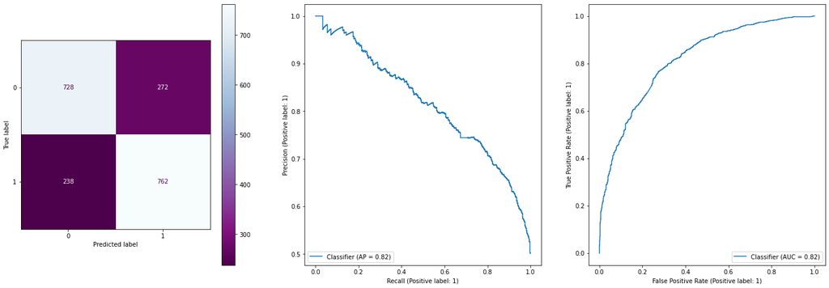

```python
dth.plot_classifier_results(None, None, sample['target'], y_pred, y_pred_prob)
```

On obtient quasiment les mêmes résultats en testant le modèle déployé sur un échantillon de 2000 tweets.